Table of contents:

- About the company
- The Business Task
- About the Dataset
- Load libraries
- Data Cleaning
- Data Explorations
- Visualization
- Summary
- Recommendations
- What’s Next
- Sources

### About the company

[Bellabeat](https://bellabeat.com) is a small high-tech manufacturer of healthy lifestyle and wellness products designed for women. The company’s mission is to empower women with information about their own wellness by collecting data on their activities, sleep, products health, and stress through the Bellabeat app. As a result, it has become successful. The co-founder and chief creative officer of Bellabeat, Urska Srsen, believes there is still room for improvement. Therefore, she has requested to analyze consumers’ habits when using a non-Bellabeat smart device to unlock new opportunities that could be implemented towards one of the Bellabeat smart products.

### The Business Task

The business task is to analyze the habits of consumers when using non-Bellabeat smart devices to unlock new opportunities that could be implemented towards one of the Bellabeat smart products to further consumers satisfaction. Therefore, the questions I need to be considering is

- What are some trends in smart device usage and how could these trends apply to Bellabeat customers?
- How could these trends help influence Bellabeat marketing strategy?

### About the Dataset

The data source is the [Fitbit Fitness tracker data](https://www.kaggle.com/arashnic/fitbit). This kaggle data contains personal fitness information from consented 33 Fitbit users regarding their daily activity like sleep monitoring, weight log, heart rate, steps, and more. I will be using this information to explore users’ habits.

I’m using RStudio to clean, process, and visualize the data set. So then I will upload the selected data that I believe will help me in identify the key habits of the consumers and make effective decisions.

### Load libraries

```r
library(lubridate)
```

```r
library(ggplot2)
library(tidyverse)
library(janitor)
library(purrr)
library(skimr)
library(dplyr)
library(hms)
```

### Import data

```r
daily_activity <- read.csv("/Users/edugenet/Desktop/Case study/Fitabase Data 4.12.16-5.12.16/dailyActivity_merged_cl.csv")

hourly_calories <- read.csv("/Users/edugenet/Desktop/Case study/Fitabase Data 4.12.16-5.12.16/hourlyCalories_merged.csv")

hourly_intensities <- read.csv("/Users/edugenet/Desktop/Case study/Fitabase Data 4.12.16-5.12.16/hourlyIntensities_merged.csv")

hourly_steps <- read.csv("/Users/edugenet/Desktop/Case study/Fitabase Data 4.12.16-5.12.16/hourlySteps_merged.csv")

daily_sleep <- read.csv("/Users/edugenet/Desktop/Case study/Fitabase Data 4.12.16-5.12.16/sleepDay_merged.csv")

weight_log <- read.csv("/Users/edugenet/Desktop/Case study/Fitabase Data 4.12.16-5.12.16/weightLoginfo_merged.csv")

heart_rate <- read.csv("/Users/edugenet/Desktop/Case study/Fitabase Data 4.12.16-5.12.16/heartrate_merged.csv")
```

### Data Cleaning

```r
#Check for correct data types, readable column names, select/reorder columns, add columns, and drop NA values.

 activity <- daily_activity %>%
   clean_names() %>%
   mutate(date = ymd(daily_activity$ActivityDate)) %>%
   select(1,16,3,4,11,12,13,14,15)

 calories <- hourly_calories %>%
   drop_na() %>%
   clean_names() %>%
   mutate(date = ymd(hourly_calories$ActivityDate))%>%
   select(1,5,3,4)

  intensities <- hourly_intensities %>%
    clean_names() %>%
    mutate(date = ymd(hourly_intensities$ActivityDate)) %>%
    select(1,6,3,4,5)

  intensities$time <- format(intensities$time, format = "%H:%M:%S")

 steps <- hourly_steps %>%
    clean_names() %>%
    mutate(date = ymd(hourly_steps$ActivityDate)) %>%
    select(1,5,3,4,)

  steps$time <- format(steps$time, format = "%H:%M:%S")


  sleep <- daily_sleep %>%
    clean_names %>%
    mutate(date = ymd(daily_sleep$SleepDay)) %>%
    select(1,7,3,4,5,6)

 daily_sleep$time <- format(daily_sleep$time, format = "%H:%M:%S")

  weight <- weight_log %>%
    clean_names() %>%
    mutate(date = ymd(weight_log$Date)) %>%
    select(1,2,3,4,6)

  heartrate <-  heart_rate %>%
    clean_names() %>%
    mutate(date = ymd(heart_rate$date))

    heartrate$time <- format(heartrate$time, format = "%H:%M:%S")
```

## Data Exploration

```r
# Check the unique number of entrys by the users for each category.

activity %>%
  group_by(activity$id) %>%
  summarise(number_of_entry = n())
```

```
## # A tibble: 33 × 2
##    `activity$id` number_of_entry
##            <dbl>           <int>
##  1    1503960366              31
##  2    1624580081              31
##  3    1644430081              30
##  4    1844505072              31
##  5    1927972279              31
##  6    2022484408              31
##  7    2026352035              31
##  8    2320127002              31
##  9    2347167796              18
## 10    2873212765              31
## # … with 23 more rows
```

```r
sleep %>%
  group_by(id) %>%
  summarise(number_of_entry = n())
```

```
## # A tibble: 24 × 2
##            id number_of_entry
##         <dbl>           <int>
##  1 1503960366              25
##  2 1644430081               4
##  3 1844505072               3
##  4 1927972279               5
##  5 2026352035              28
##  6 2320127002               1
##  7 2347167796              15
##  8 3977333714              28
##  9 4020332650               8
## 10 4319703577              26
## # … with 14 more rows
```

```r
weight %>%
  group_by(id) %>%
  summarise(number_of_entry = n())
```

```
## # A tibble: 8 × 2
##           id number_of_entry
##        <dbl>           <int>
## 1 1503960366               2
## 2 1927972279               1
## 3 2873212765               2
## 4 4319703577               2
## 5 4558609924               5
## 6 5577150313               1
## 7 6962181067              30
## 8 8877689391              24
```

```r
steps %>%
  group_by(id) %>%
  summarise(number_of_entry = n()/24)
```

```
## # A tibble: 33 × 2
##            id number_of_entry
##         <dbl>           <dbl>
##  1 1503960366            29.9
##  2 1624580081            30.7
##  3 1644430081            29.5
##  4 1844505072            30.5
##  5 1927972279            30.7
##  6 2022484408            30.7
##  7 2026352035            30.7
##  8 2320127002            30.6
##  9 2347167796            17.2
## 10 2873212765            30.7
## # … with 23 more rows
```

```r
#calories %>%
  #group_by(id) %>%
  #summarise(number_of_entry = n()/24)

intensities %>%
  group_by(id) %>%
  summarise(number_of_entry = n()/24)
```

```
## # A tibble: 33 × 2
##            id number_of_entry
##         <dbl>           <dbl>
##  1 1503960366            29.9
##  2 1624580081            30.7
##  3 1644430081            29.5
##  4 1844505072            30.5
##  5 1927972279            30.7
##  6 2022484408            30.7
##  7 2026352035            30.7
##  8 2320127002            30.6
##  9 2347167796            17.2
## 10 2873212765            30.7
## # … with 23 more rows
```

```r
#Check the number of participants in each cataegory

n_distinct(activity$id)
```

```
## [1] 33
```

```r
n_distinct(intensities$id)
```

```
## [1] 33
```

```r
n_distinct(calories$id)
```

```
## [1] 0
```

```r
n_distinct(sleep$id)
```

```
## [1] 24
```

```r
n_distinct(steps$id)
```

```
## [1] 33
```

```r
n_distinct(weight$id)
```

```
## [1] 8
```

```r
n_distinct(heartrate$id)
```

```
## [1] 7
```

Now, let’s check the relationship between activity and sleep.

```r
#Check relationship between activity and sleep.

sleep_steps <- merge(sleep, steps, by.x = "id", by.y = "id")

sleep_steps %>%
  select(total_minutes_asleep) %>%
  summary()
```

```
##  total_minutes_asleep
##  Min.   : 58.0
##  1st Qu.:361.0
##  Median :432.0
##  Mean   :419.6
##  3rd Qu.:492.0
##  Max.   :796.0
```

```r
activity %>%
  select(lightly_active_minutes,
         fairly_active_minutes,
         very_active_minutes,
         sedentary_minutes) %>%
  summary()
```

```
##  lightly_active_minutes fairly_active_minutes very_active_minutes
##  Min.   :  0.0          Min.   :  0.00        Min.   :  0.00
##  1st Qu.:127.0          1st Qu.:  0.00        1st Qu.:  0.00
##  Median :199.0          Median :  6.00        Median :  4.00
##  Mean   :192.8          Mean   : 13.56        Mean   : 21.16
##  3rd Qu.:264.0          3rd Qu.: 19.00        3rd Qu.: 32.00
##  Max.   :518.0          Max.   :143.00        Max.   :210.00
##  sedentary_minutes
##  Min.   :   0.0
##  1st Qu.: 729.8
##  Median :1057.5
##  Mean   : 991.2
##  3rd Qu.:1229.5
##  Max.   :1440.0
```

The average amount of sleep for the participants is almost 7 hours, and sedentary minutes are 16 hours. According to [health.gov](https://www.heart.org/en/healthy-living/fitness/fitness-basics/target-heart-rates), most adults need to get at least 7 hours of quality sleep on a regular schedule daily for better health and optimal productivity. In the app, a reminder can be set when a user goes sedentary for an extended period of time.

## Visualization

```r
#summarise and visualize the relationship between steps and calories

activity%>%
  select(total_steps, calories) %>%
  summary()
```

```
##   total_steps       calories
##  Min.   :    0   Min.   :   0
##  1st Qu.: 3790   1st Qu.:1828
##  Median : 7406   Median :2134
##  Mean   : 7638   Mean   :2304
##  3rd Qu.:10727   3rd Qu.:2793
##  Max.   :36019   Max.   :4900
```

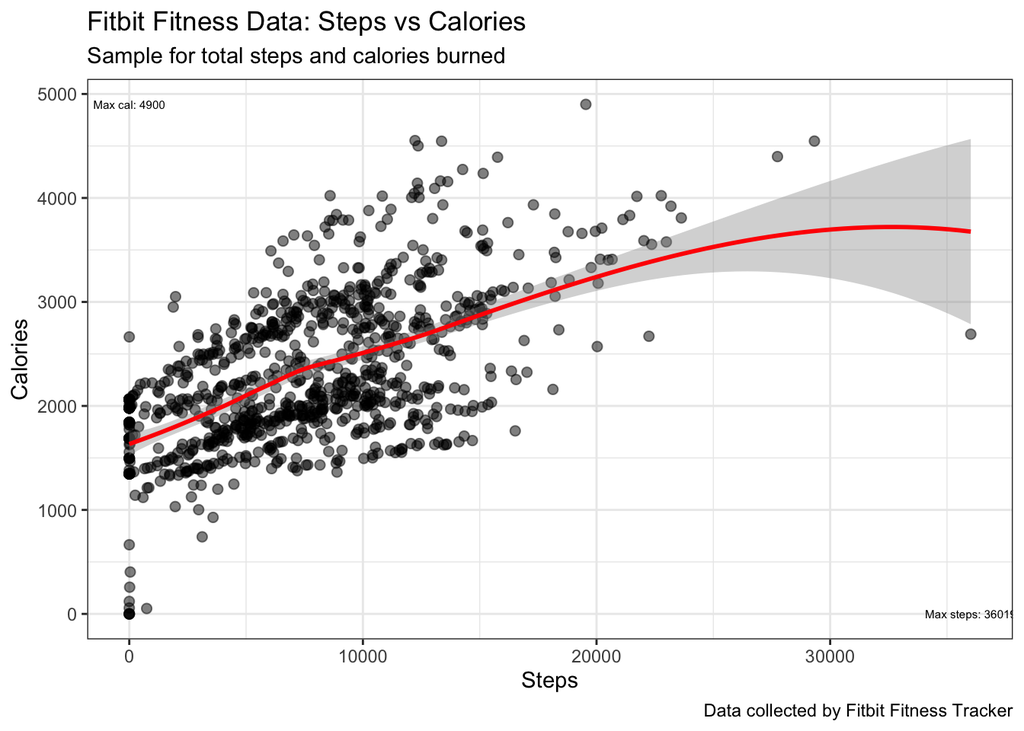

```r
ggplot(data = activity,
       mapping = aes(x = total_steps,
                     y = calories)) +
  geom_point(size = 2, alpha = 0.5) +
  geom_smooth(color = "red") +
  labs(title = "Fitbit Fitness Data: Steps vs Calories",
       subtitle = "Sample for total steps and calories burned",
       caption = "Data collected by Fitbit Fitness Tracker", x = "Steps", y = "Calories") +
  annotate("text", x = 36019, y = 0,
           label= " Max steps: 36019 ", size = 2) +
  annotate("text", x = 0, y = 4900,
           label= " Max cal: 4900 ", size = 2) +
  theme_bw()
```

The plot shows there is a positive correlation between steps and calories. The more steps we take, the more calories we burn.

```r
# Create a new table showing the min, avg, and max heartrate per id.

heartrate_tab <- heartrate %>%
  group_by(id) %>%
  summarise( min_rate =  min(value),
             Avg_rate = mean(value),
             max_rate = max(value))  %>%
  arrange(Avg_rate) %>%
  view()
```

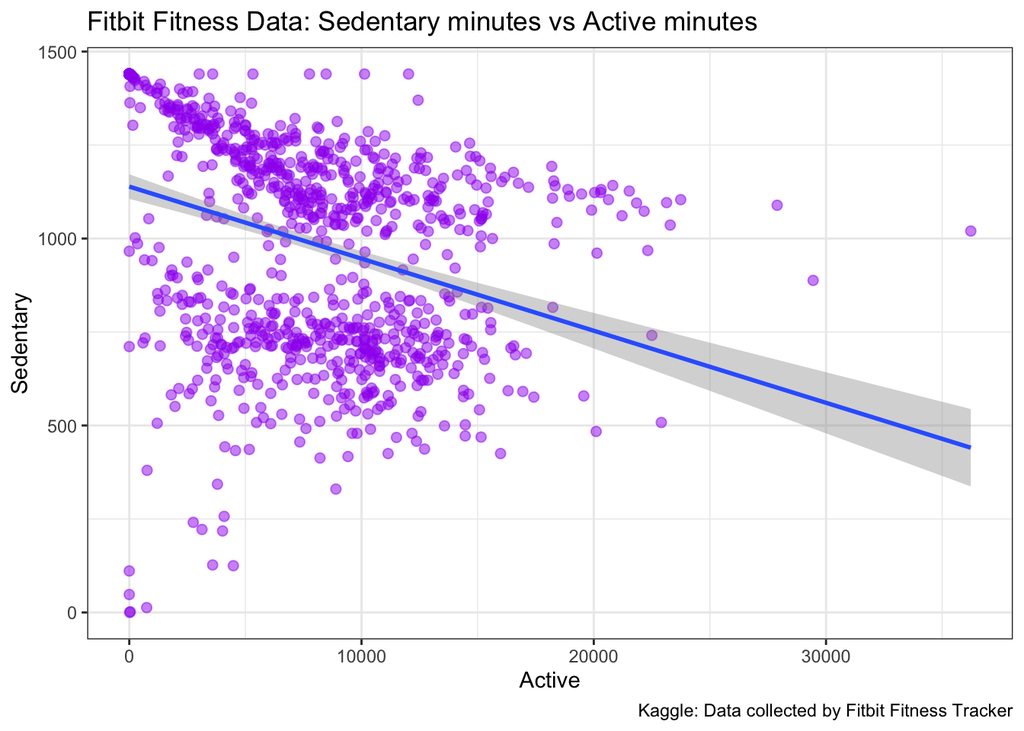

```r
#Add all the active minutes including very, fairly and lightly active minutes and compare to sedentary minutes

activity %>%
  drop_na() %>%
  mutate(total_active_min = rowSums(activity[, c(3,4,5)], na.rm=TRUE)) %>%
  ggplot(activity, mapping= aes(total_active_min, sedentary_minutes)) +
  geom_point(size = 2, color  = "purple", alpha = 0.5 ) +
  geom_smooth(method= lm) +
  labs(x = "Active",
       y = "Sedentary",
       title = "Fitbit Fitness Data: Sedentary minutes vs Active minutes ",
       caption = "Kaggle: Data collected by Fitbit Fitness Tracker") +
  theme_bw()
```

Now let’s analyze the BMI range.

```r
    weight2 <- merge(weight, intensities, by.x = "id", by.y = "id")
    head(weight2)
```

```
##           id     date.x weight_kg weight_pounds   bmi     date.y     time
## 1 1503960366 2016-05-02      52.6        115.96 22.65 2016-04-29 13:00:00
## 2 1503960366 2016-05-02      52.6        115.96 22.65 2016-04-29 7:00:00
## 3 1503960366 2016-05-02      52.6        115.96 22.65 2016-04-29 8:00:00
## 4 1503960366 2016-05-02      52.6        115.96 22.65 2016-04-29 12:00:00
## 5 1503960366 2016-05-02      52.6        115.96 22.65 2016-05-11 8:00:00
## 6 1503960366 2016-05-02      52.6        115.96 22.65 2016-04-29 9:00:00
##   total_intensity average_intensity
## 1               6              0.10
## 2               3              0.05
## 3              13              0.22
## 4               6              0.10
## 5              21              0.35
## 6              33              0.55
```

Recode the BMI numeric values with the standard weight status categories, which can be found at [cdc.gov](https://www.cdc.gov/healthyweight/assessing/bmi/adult_bmi/index.html)

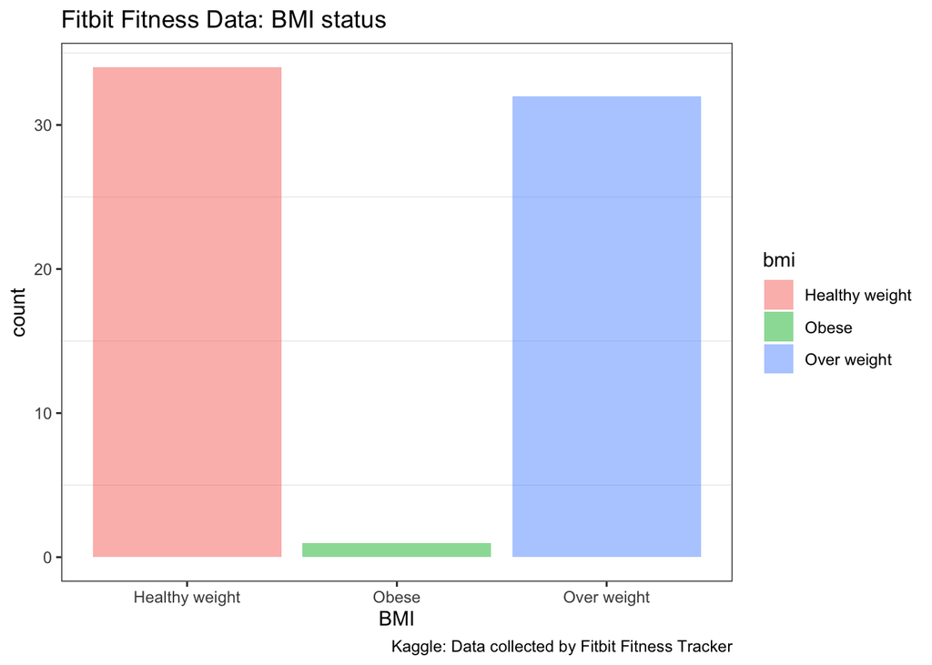

```r
#Catagorize BMI numeric value by the standard range

    weight2 <- weight %>%
    group_by(id) %>%
    mutate(bmi = if_else(bmi >= 18.5 & bmi <= 24.9, "Healthy weight",
           if_else(bmi < 18.5, "Under weight",
           if_else(bmi >= 25 & bmi <= 29.9, "Over weight",
           if_else(bmi >= 30, "Obese", "Wrong Value")))))

    weight2 %>%
      drop_na(bmi) %>%
      ggplot(aes(x = bmi, fill = bmi)) +
      geom_bar(position = "dodge", alpha = 0.5) +
      labs( x = "BMI",
            Y = NULL,
            title = "Fitbit Fitness Data: BMI status",
            caption = "Kaggle: Data collected by Fitbit Fitness Tracker") +
      theme_bw() +
      theme(panel.grid.major = element_blank())
```

```r
    weight2 %>%
      group_by(bmi) %>%
      group_by(bmi) %>%
      summarise(n_distinct(id))
```

```
## # A tibble: 3 × 2
##   bmi            `n_distinct(id)`
##   <chr>                     <int>
## 1 Healthy weight                3
## 2 Obese                         1
## 3 Over weight                   4
```

The bar plot and the summary shows that out of the 8 participants, 3 are a healthy weight, 4 are overweight and 1 is obese. Having this type of report in the app can be significant in improving one’s weight/BMI goal. A default notification for a weekly report with a custom option can be added to the app.

let’s evaluate the Pivot table showing the time of the day when a user is most active.

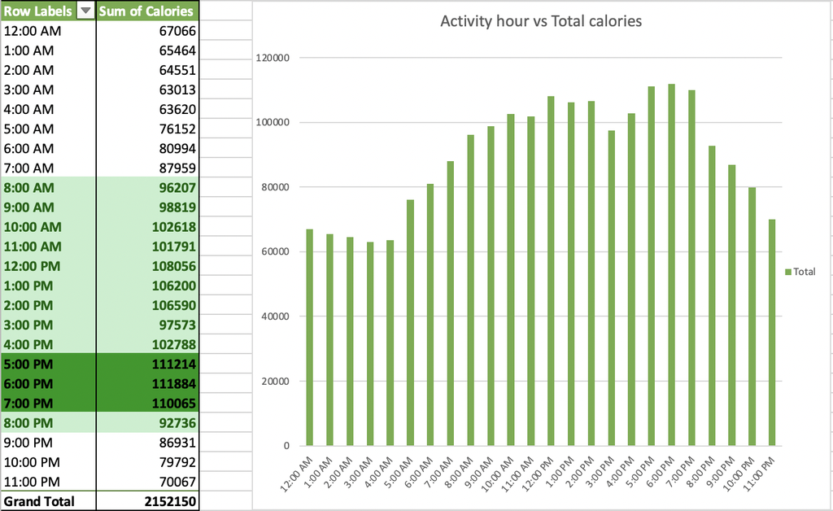

Most active hours of the day

The summary shows that the most active hours of the day are between 5:00 PM - and 7:00 PM. 10:00 AM - 7:00 PM is generally active. Therefore, a reminder notification can be set up around this time frame.

## Summary

The target market for Bellabeat is women. And a marketing strategy that focuses on both practicality and fashion is preferred by most, which is why the company has been successful. I believe promoting fashionable products that are equipped with current technology are desirable and smart business ventures.

The trend in smart devices is primarily voice assistance and wearable devices, which is a great opportunity for Bellabeat since they carry a watch called TIme. [Time] (https://bellabeat.com/time/) is a fashionable hybrid tracker watch that helps improve body wellness by tracking activity and sleep. And it comes in two classic colors, silver and rose gold.

The app does a great job of displaying wellness reports. But it would also be a significant improvement to be further developed to support voice assistance, which in turn maximizes customer satisfaction and will drive up sales and continue the company’s success.

I strongly believe that customer satisfaction is key to a company’s growth.

## Recommendations

In addition to adding voice assistance, I also recommend adding and setting the following notifications and reminders when.

- A user goes inactive for an extended period of time
- Heart rate goes over the normal range along with suggestions to bring the rate down to a normal range
- A user hits their goal and also when they are close to keeping them motivated
- It’s time to sleep
- It’s around the time when they are most active to keep them consistent

some customers may also enjoy reading motivational quotes or reading testimonials from other users as well. So that can also be an optional notification.

### What’s next?

- Collect more data on weight, heart rate and intensity categories
- In the Bellabeat app, create an interacive servey that can be taken when a user is consistently active, and use that data to stay current and keep improving app performance

THANK YOU for your time!

### Sources:

American Heart Association Editorial Staff And Reviewed By Science And Medicine Advisers. (2021). Target Heart Rates Chart. Retrieved from https://www.heart.org/en/healthy-living/fitness/fitness-basics/target-heart-rates

Raymond, M. (n.d.).Usage and Buying Trends in Smart Home Devices: GoodFirms Research. Www.goodfirms.co. https://www.goodfirms.co/resources/buying-smart-home-devices-statistics

Marr, B. (2021, September 27).The 5 Biggest Technology Trends In 2022. Forbes. https://www.forbes.com/sites/bernardmarr/2021/09/27/the-5-biggest-technology-trends-in-2022/?sh=4f857cc24147

https://bellabeat.com